# round3-wallnowall

The speaker was at ~2.1 m to avoid directionality effects.

[figure not shown]

GRAS mic without wall (picture has grid, but all recordings done without grid)

[figure not shown]

Knowles SPU0410 mics recorded without wall.

[figure not shown]

GRAS mic flush with wall

[figure not shown]

Knowles mics flush with wall (also including speaker )

[figure not shown]

Knowles mics flush with wall

```python
import datetime as dt
import glob
import os
import matplotlib.pyplot as plt
from matplotlib.gridspec import GridSpec
import numpy as np
import pandas as pd
import soundfile as sf
import scipy.signal as signal
import tqdm
from playback_code import playback_analysis as pa
from fullscale_calculations import *
```

```python
print(f'This cell was run at: {dt.datetime.now()}')
```

```
This cell was run at: 2021-05-27 13:53:30.197891
```

```python
def get_loudest_part(X, fs=192000, winsize=0.025):
    x_sq = np.sqrt(np.abs(X)**2)
    winsamples = int(fs*winsize)
    running_mean = np.convolve(x_sq, np.ones(winsamples)/winsamples, mode='same')
    threshold = np.percentile(running_mean, [10,90])
    indices = np.logical_and(running_mean >=threshold[0], running_mean>=threshold[1])
    return indices, running_mean
```

```python
def calculate_tones_rec_level(audio, fs, tone_freqs, FS_dbu, gain, sensitivity_dbvrms, freq_bw=500):
    '''
    '''

    audio_parts = np.array_split(audio, len(tone_freqs))

    tones_rms = []
    for peak_freq, tone_part in zip(tone_freqs, audio_parts):
        loudest_inds, _ = get_loudest_part(tone_part, fs=fs)
        audio_part = tone_part[loudest_inds]
        signal_fft = np.fft.fft(audio_part)
        fftfreqs = np.fft.fftfreq(audio_part.size, 1/fs)
        if np.logical_or(peak_freq<=0, peak_freq>=fs*0.5):
            raise ValueError(f'A peakfrequency <0 or > Nyquist frequency ({peak_freq}Hz) has been detected. Aborting....')
        signal_band = np.array([peak_freq-freq_bw, peak_freq+freq_bw])
        signal_band[signal_band<0] = 0
        signal_band[signal_band>fs*0.5] = fs*0.5
        rms_value = pa.extract_bandrms_from_fft(signal_band, signal_fft, fftfreqs)
        tones_rms.append(rms_value)

    #tones_rms = pa.get_tones_rms(audio, tone_freqs,fs=fs,bandwidth=freq_bw)
    tones_rms = pd.DataFrame(data={'tone_rms':tones_rms})
    max_rms = 1/(np.sqrt(2)) # for Vp=1 Vrms = (1/sqrt(2))*Vp
    tones_rms['dbrms_re_max'] = pa.dB(tones_rms['tone_rms']/max_rms)
    tones_rms['dbrms_wogain'] = tones_rms['dbrms_re_max']-gain
    tones_rms['db_FS'] = pa.dB(dbu2vrms(FS_dbu))
    tones_rms['tone_db'] = tones_rms['db_FS'] + tones_rms['dbrms_wogain']
    tones_rms['tone_freqs'] = tone_freqs
    sensitivity_vrms = 10**(sensitivity_dbvrms/20.0) # Vrms/Pa
    ref = 20*10**-6 # Pa

    tones_rms['Pa_rms'] = 10**(tones_rms['tone_db']/20.0)*(1/sensitivity_vrms)
    tones_rms['dbspl_rms'] = pa.dB(tones_rms['Pa_rms']/ref)
    return tones_rms
```

```python
%matplotlib notebook
```

### How stable is the speaker playback

```python
on_axis_gras = glob.glob('2021-05-06/gras-*_angle_0*.wav')
on_axis_gras
```

```
['2021-05-06\\gras-2mwall-flush_gaindB_70_azimuth_angle_0_2021-05-06_14-51-44.wav',
 '2021-05-06\\gras-2mwall-flush_gaindB_70_azimuth_angle_0_2021-05-06_14-52-10.wav',
 '2021-05-06\\gras-2mwall-flush_gaindB_70_azimuth_angle_0_2021-05-06_14-54-36.wav',
 '2021-05-06\\gras-2mwall-flush_gaindB_70_azimuth_angle_0_2021-05-06_14-55-00.wav',
 '2021-05-06\\gras-2mwall-flush_gaindB_70_azimuth_angle_0_2021-05-06_15-21-07.wav',
 '2021-05-06\\gras-2mwall-flush_gaindB_70_azimuth_angle_0_2021-05-06_15-23-10.wav',
 '2021-05-06\\gras-2mwall-notflush170mm_gaindB_76_azimuth_angle_0_2021-05-06_14-57-30.wav',
 '2021-05-06\\gras-2mwall-notflush170mm_gaindB_76_azimuth_angle_0_2021-05-06_14-57-56.wav',
 '2021-05-06\\gras-2mwall-notflush170mm_gaindB_76_azimuth_angle_0_2021-05-06_15-00-17.wav',
 '2021-05-06\\gras-2m_gaindB_70_azimuth_angle_0_2021-05-06_14-38-30.wav',
 '2021-05-06\\gras-2m_gaindB_70_azimuth_angle_0_2021-05-06_14-41-56.wav',
 '2021-05-06\\gras-2m_gaindB_70_azimuth_angle_0_2021-05-06_14-42-47.wav']
```

```python
def extract_time_and_ttmt(fname):
    parts = os.path.split(fname)[-1].split('_')
    return parts[0]+'_'+parts[-1]
unique_onaxis  = [extract_time_and_ttmt(each) for each in on_axis_gras]
```

```python
fireface_dbu_FS = 27
gras_dbVrmsPa = -49.17
gras_gain = 70
gras_datasheet_freqs = np.arange(20,90,5)*10**3
```

```python
freqs = np.arange(10000, 95000, 1000)
all_rec_data = []
onaxis_data = []
for identifier, filename in tqdm.tqdm(zip(unique_onaxis, on_axis_gras)):
    audio, fs = sf.read(filename)
    tones = pa.get_only_tones(audio, 1.5)
    b,a = signal.butter(2, np.array([9000,95500])/(fs*0.5), 'bandpass')
    tones_bp = signal.lfilter(b,a,tones)

    tones_parts = np.array_split(tones_bp, 85)
    tones_level = calculate_tones_rec_level(tones_bp, fs, freqs, fireface_dbu_FS, gras_gain, gras_dbVrmsPa,freq_bw=250)
    relevant_rows = np.flatnonzero(np.isin(tones_level['tone_freqs'].to_numpy(),gras_datasheet_freqs))
    tones_data_subs = tones_level.loc[relevant_rows,['tone_freqs','dbspl_rms']]
    tones_data_subs['identifier'] = identifier
    onaxis_data.append(tones_data_subs)
    all_rec_data.append(tones_level)
```

```
12it [00:47,  3.93s/it]
```

```python
onaxis_gras = pd.concat(onaxis_data)
```

```python
linetypes = ['k*','r*','g*']
```

```python
onaxis_gras['recgroup'] = onaxis_gras['identifier'].apply(lambda X: X.split('_')[0])
```

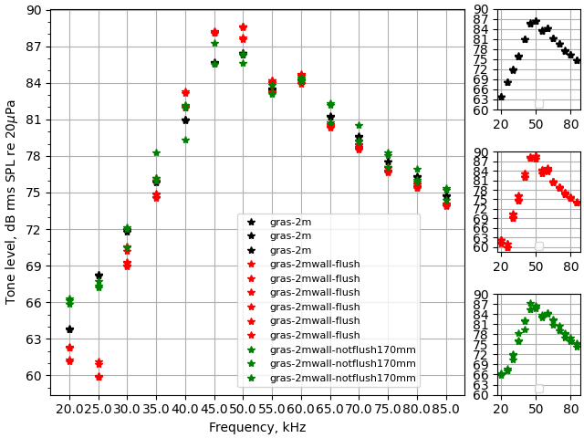

```
No handles with labels found to put in legend.
No handles with labels found to put in legend.
No handles with labels found to put in legend.
```

```
 [Text(20000, 0, '20'), Text(50000, 0, '50'), Text(80000, 0, '80')])
```

```python
from matplotlib.ticker import (MultipleLocator, AutoMinorLocator)
fig = plt.figure(constrained_layout=True)

gs = GridSpec(6, 6, figure=fig)

main = fig.add_subplot(gs[:, :5])

for ttmt, df in onaxis_gras.groupby('identifier'):
    if '-2m_' in ttmt:
        linecol = linetypes[0]
    elif '-2mwall-flush' in ttmt:
        linecol = linetypes[1]
    else:
        linecol = linetypes[2]
    plt.plot(df['tone_freqs'], df['dbspl_rms'],linecol, label=ttmt.split('_')[0])
plt.legend(loc=(0.45, 0.02), fontsize=8)
plt.grid();plt.yticks(np.arange(60,92,3));
plt.xticks(gras_datasheet_freqs, gras_datasheet_freqs*10**-3);plt.ylabel('Tone level, dB rms SPL re 20$\mu$Pa')
plt.xlabel('Frequency, kHz')

nowall = fig.add_subplot(gs[:2, 5:])
nowall_msmts = onaxis_gras[onaxis_gras['recgroup'] == 'gras-2m']
plt.plot(nowall_msmts['tone_freqs'], nowall_msmts['dbspl_rms'],linetypes[0])
plt.legend(loc=(0.45, 0.02), fontsize=8)
plt.grid();plt.yticks(np.arange(60,92,3));plt.xticks([20000,50000, 80000],[20,50,80])
main.yaxis.set_minor_locator(MultipleLocator(1))

wallflush = fig.add_subplot(gs[2:4, 5:])
wallflush_msmts = onaxis_gras[onaxis_gras['recgroup'] == 'gras-2mwall-flush']
plt.plot(wallflush_msmts['tone_freqs'], wallflush_msmts['dbspl_rms'],linetypes[1])
plt.legend(loc=(0.45, 0.02), fontsize=8)
plt.grid();plt.yticks(np.arange(60,92,3));plt.xticks([20000,50000, 80000],[20,50,80])



notwallflush = fig.add_subplot(gs[4:, 5:])
notwallflush_msmts = onaxis_gras[onaxis_gras['recgroup'] == 'gras-2mwall-notflush170mm']
plt.plot(notwallflush_msmts['tone_freqs'], notwallflush_msmts['dbspl_rms'],linetypes[2])
plt.legend(loc=(0.45, 0.02), fontsize=8)
plt.grid();plt.yticks(np.arange(60,92,3));plt.xticks([20000,50000, 80000],[20,50,80])
```

## *Speaker variability still remains an issue with pure tones!!!!*

Here I'm only looking at a subset of frequencies - and already at 40 kHz (not flush with wall) there's a difference of ~ 3 dB in the source levels!!! This is despite not changing anything.

## What if we analyse only the sweeps?

The sweeps are short sounds that may not create the same weird effect that longer tones do. Does using sweeps reduce the weird variation?

```python
onaxis_gras_sweep_ffts = {}

b,a = signal.butter(2, np.array([9000,95500])/(fs*0.5), 'bandpass')
for identifier, filename in tqdm.tqdm(zip(unique_onaxis, on_axis_gras)):
    audio, fs = sf.read(filename)
    sweeps = np.array_split(audio[int(fs*0.5):int(fs*1.5)],5)

    sweep_ffts = {}

    for i,each in enumerate(sweeps):
        sweeps_bp = signal.lfilter(b,a,each)
        sweepregion, _ = get_loudest_part(sweeps_bp)
        sweep_only = sweeps_bp[sweepregion]
        sweeps_fft = 20*np.log10(np.abs(np.fft.rfft(sweep_only)))
        sweeps_freq = np.fft.rfftfreq(sweep_only.size,1.0/fs)
        sweep_ffts[i] = np.column_stack((sweeps_freq, sweeps_fft))
    onaxis_gras_sweep_ffts[identifier] = sweep_ffts
```

```
12it [00:03,  3.78it/s]
```

```python
recordings = list(onaxis_gras_sweep_ffts.keys())
recordings
```

```
['gras-2mwall-flush_14-51-44.wav',
 'gras-2mwall-flush_14-52-10.wav',
 'gras-2mwall-flush_14-54-36.wav',
 'gras-2mwall-flush_14-55-00.wav',
 'gras-2mwall-flush_15-21-07.wav',
 'gras-2mwall-flush_15-23-10.wav',
 'gras-2mwall-notflush170mm_14-57-30.wav',
 'gras-2mwall-notflush170mm_14-57-56.wav',
 'gras-2mwall-notflush170mm_15-00-17.wav',
 'gras-2m_14-38-30.wav',
 'gras-2m_14-41-56.wav',
 'gras-2m_14-42-47.wav']
```

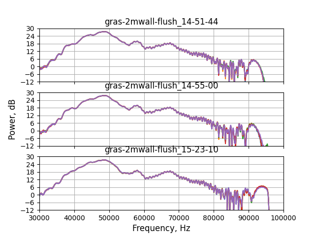

```python
plt.figure()
plt.subplot(311)
for i in range(5):
    freqs = onaxis_gras_sweep_ffts[recordings[0]][i][:,0]
    spec = onaxis_gras_sweep_ffts[recordings[0]][i][:,1]
    plt.plot(freqs, spec);plt.xticks(np.arange(30000,110000,10000),[])
plt.ylim(-10,30);plt.grid();plt.xlim(30000,100000);plt.yticks(np.arange(-12,36,6));
plt.title('gras-2mwall-flush_14-51-44')

plt.subplot(312)
for i in range(5):
    freqs = onaxis_gras_sweep_ffts[recordings[3]][i][:,0]
    spec = onaxis_gras_sweep_ffts[recordings[3]][i][:,1]
    plt.plot(freqs, spec);plt.xticks(np.arange(30000,110000,10000),[])
plt.ylim(-10,30);plt.grid();plt.xlim(30000,100000);plt.yticks(np.arange(-12,36,6));
plt.ylabel('Power, dB', fontsize=12);plt.title('gras-2mwall-flush_14-55-00');

plt.subplot(313)
for i in range(5):
    freqs = onaxis_gras_sweep_ffts[recordings[5]][i][:,0]
    spec = onaxis_gras_sweep_ffts[recordings[5]][i][:,1]
    plt.plot(freqs, spec)
plt.ylim(-10,30);plt.grid();plt.xlim(30000,100000);plt.yticks(np.arange(-12,36,6));
plt.xlabel('Frequency, Hz', fontsize=12);plt.title('gras-2mwall-flush_15-23-10');
```

#### Sweeps show high intra-playback consistency.

```python
def make_avged_fft(recording_name, fft_dictionary):
    # first check all ffts are the same size
    fft_sizes = [len(fft_dictionary[recording_name][i][:,1]) for i in range(5)]
    if not np.all(np.array(fft_sizes)==fft_sizes[0]):
        raise ValueError(f'all FFTs not same size: {fft_sizes}')

    all_ffts = np.array([fft_dictionary[recording_name][i][:,1] for i in range(5)]).reshape(5,-1)
    avg_fft = 20*np.log10(np.mean(10**(all_ffts/20.0), axis=0))
    freqs = fft_dictionary[recording_name][0][:,0]
    return avg_fft, freqs
```

```python
recordings
```

```
['gras-2mwall-flush_14-51-44.wav',
 'gras-2mwall-flush_14-52-10.wav',
 'gras-2mwall-flush_14-54-36.wav',
 'gras-2mwall-flush_14-55-00.wav',
 'gras-2mwall-flush_15-21-07.wav',
 'gras-2mwall-flush_15-23-10.wav',
 'gras-2mwall-notflush170mm_14-57-30.wav',
 'gras-2mwall-notflush170mm_14-57-56.wav',
 'gras-2mwall-notflush170mm_15-00-17.wav',
 'gras-2m_14-38-30.wav',
 'gras-2m_14-41-56.wav',
 'gras-2m_14-42-47.wav']
```

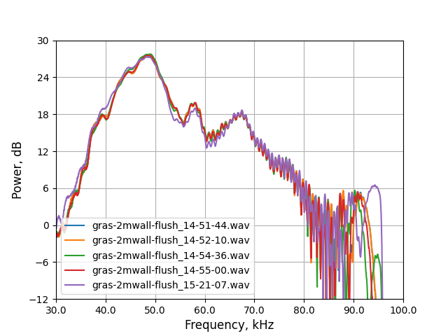

```python
plt.figure()
for i in range(5):
    avgd_fft, freqs = make_avged_fft(recordings[i], onaxis_gras_sweep_ffts)
    plt.plot(freqs, avgd_fft, label=recordings[i]);
plt.xticks(np.arange(30000,110000,10000),np.arange(30000,110000,10000)*0.001)
plt.ylim(-10,30);plt.grid();plt.xlim(30000,100000);
plt.yticks(np.arange(-12,36,6));
plt.legend();plt.ylabel('Power, dB',fontsize=12);plt.xlabel('Frequency, kHz',fontsize=12)
```

```python
all_avg_ffts = []
for i in range(5):
    avgd_fft, freqs = make_avged_fft(recordings[i], onaxis_gras_sweep_ffts)
    all_avg_ffts.append(avgd_fft)

# compare to first playback
norm_first_pbk = np.column_stack((all_avg_ffts[0]-all_avg_ffts[i] for i in range(1,len(all_avg_ffts))) )
```

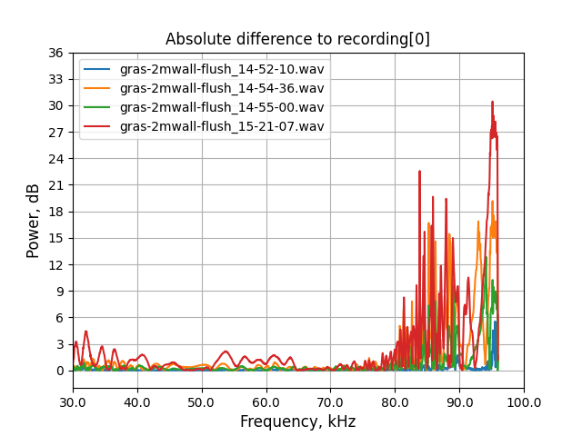

```python
plt.figure()
for i in range(4):
    plt.plot(freqs, np.abs(norm_first_pbk[:,i]),label=recordings[i+1])

plt.xticks(np.arange(30000,110000,10000),np.arange(30000,110000,10000)*0.001)
plt.ylim(-2,30);plt.grid();plt.xlim(30000,100000);
plt.yticks(np.arange(0,39,3));
plt.legend();plt.ylabel('Power, dB',fontsize=12);plt.xlabel('Frequency, kHz',fontsize=12)
plt.title('Absolute difference to recording[0]')
```

### Variation across playbacks remains even for sweeps!!

Even with sweeps - there's a variation in the playback level across time. There's more variation for frequencies > 80kHz, though even already at <40 kHz too!

## What now?

Well - I need to finally explore the other speakers + pre-amps and see which combination gives the most stable playback levels.

2021-05-27